# MPDW Latihan 4

Windi Gunawan

2023-09-21

## White Noise

Pembangkitan data berpola AR, MA, ARMA, dan banyak proses deret waktu lainnya diawali pembangkitan *white noise*. *White noise* merupakan sederet nilai dari peubah bebas stokastik identik. Oleh karena itu, *white noise* memiliki dua karakteristik penting:

1. *White noise* tidak memiliki autokorelasi (**karena saling bebas**)
2. Nilai harapan dan ragam *white noise* sama (**karena berasal dari peubah acak bebas stokastik identik**)

*White noise* dibangkitkan dari suatu peubah acak, umumnya peubah acak normal.

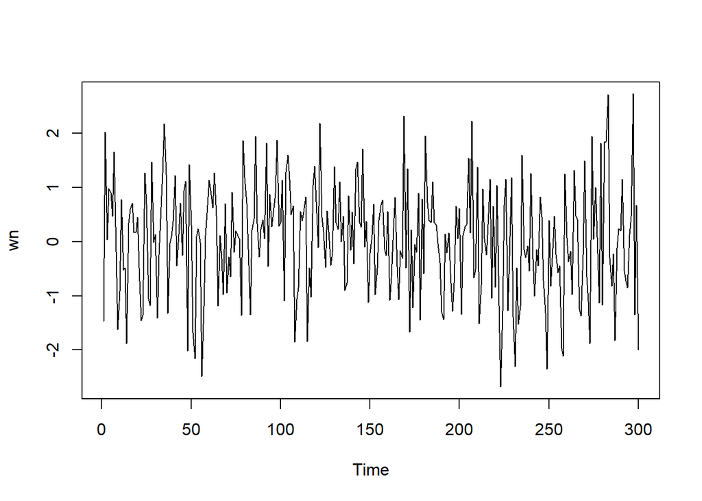

```r
wn <- rnorm(300)
ts.plot(wn)
```

Dapat terlihat bahwa *white noise* tidak memiliki autokorelasi dari ACF. Perhatikan bahwa lag ke-0 adalah korelasi observasi ke-t dengan dirinya sendiri. Nilai korelasi tersebut pasti 1. Sebagai alternatif, lag pertama di plot ACF dapat ditetapkan sebagai 1 (alih-alih 0) dengan menambahkan argumen `xlim(1, lag akhir)`. Plot tersebut dapat disandingkan bersamaan dengan membuat matriks $1 \times 2$ dengan `par(mfrow = c(1,2))`.

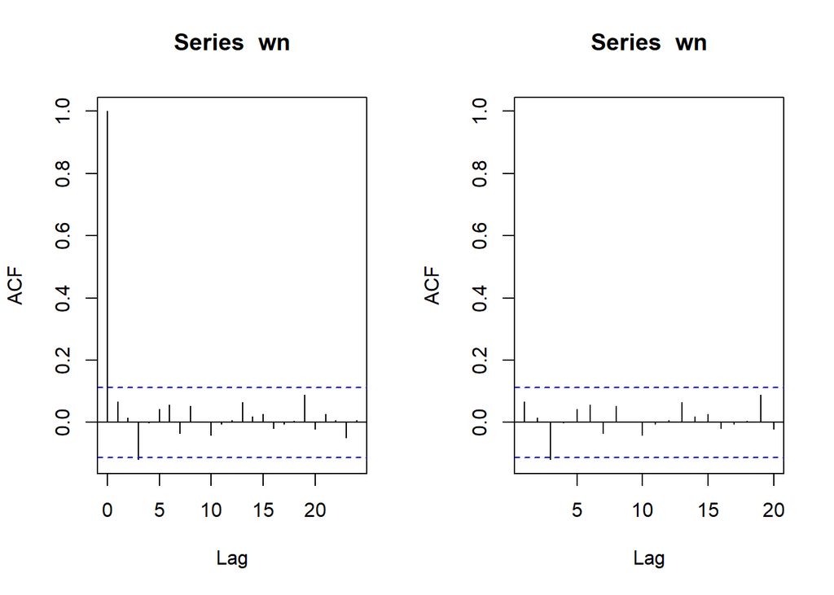

```r
par(mfrow = c(1, 2))
acf(wn)
acf(wn, xlim = c(1, 20))
```

## Proses MA

Proses MA dapat dituliskan sebagai berikut:

$$y_{t} = c + e_t + \theta_{1}e_{t-1} + \theta_{2}e_{t-2} + \dots +
\theta_{q}e_{t-q} = c+{e_t+\sum_{i=1}^p \theta_ie_{t-i}}$$
Terlihat bahwa $e_t$, atau *white noise*, berperan penting dalam pembangkitan proses MA.

## Pembangkitan Proses MA(2)

```r
set.seed(082)
ma <- wn[1:2]
ma
```

```
## [1] -1.468167  2.018194
```

Nilai-nilai selanjutnya dapat dicari melalui *loop*. Bentuk loop dapat dilihat dari rumus MA(2) yang hendak dibangkitkan:

$$y_t = e_t+0.4e_{t-1}+0.6e_{t-2}$$

```r
for(i in 3:300){
   ma[i] <- wn[i] + 0.4 * wn[i - 1] + 0.6 * wn[i - 2]
}
ma
```

```
##   [1] -1.468167041  2.018194204 -0.037321398  2.207789628  1.321635177
##   [6]  1.418503412  2.386721617  0.761864957 -0.700013958 -1.669119398
##  [11] -0.562353857 -0.758113594 -0.228701184 -2.384695368 -0.700762798
##  [16] -0.395542771  1.149349885  0.810867222  0.667099806  0.627940686
##  [21] -0.195391124 -1.373727403 -2.228933652 -0.145201227  0.381400717
##  [26] -0.015009576 -1.183671644  0.368739310 -0.124347880  1.009261216
##  [31] -1.360401483 -0.727153707 -0.517002982  1.295448000  2.934500887
##  [36]  2.867601065  0.478967796  0.184290325 -0.700136581  0.393597116
##  [41]  1.431157016  0.266501667  0.684708483  0.495648728  0.105008835
##  [46]  1.261688902  1.336396580 -1.008112472  1.284067010 -0.331919509
##  [51] -0.703999338 -2.647103465 -1.778571681 -1.020233570  0.143856107
##  [56] -2.348151877 -2.192352610 -1.860277840 -0.001971726  1.472464030
##  [61]  1.795526681  1.686673369  2.084494636  1.365956368 -0.233919864
##  [66] -0.074854046 -0.975522092 -1.031176686  0.130163870 -1.247459271
##  [71] -0.239094920 -1.325299862  0.484956954 -0.216970081  0.672303509
```

[output cut: 45 more lines]

Selain menggunakan cara di atas, pembangkitan proses MA(2) dapat dilakukan dengan fungsi `arima.sim()` sebagai berikut.

```r
ma2 <- arima.sim(list(order=c(0,0,2), ma=c(0.4,0.6)), n=300)
ma2
```

```
## Time Series:
## Start = 1
## End = 300
## Frequency = 1
##   [1] -0.940872468 -1.353387401 -0.538348652 -1.193187568 -0.080827710
##   [6] -1.229212340 -1.063667036  1.844066968  0.196857922  1.074799710
##  [11] -0.461177166 -0.535630278 -1.053034231 -0.113888668 -0.729273656
##  [16]  0.726581217  1.227406750  1.491844385  0.689917212  1.796879789
##  [21]  0.402728433 -0.539513574 -0.122276241 -1.082283018 -1.065226223
##  [26] -0.641014426 -0.498090549  1.140262418  1.480395533 -0.368515778
##  [31]  0.035437289 -1.345766177  0.392611931  0.863219985 -0.121076596
##  [36] -0.552743693  0.540499212 -1.620915815 -0.114380465  1.025006399
##  [41]  0.042425660 -0.242257027 -1.109237704  1.445652859 -0.394107168
##  [46]  2.630860793  0.425797997  0.050154304  1.261508664  1.351061871
##  [51]  2.150713194  0.113036848 -1.444575721 -1.065352277 -0.723968840
```

[output cut: 49 more lines]

## Karakteristik MA(2)

### Plot Time Series

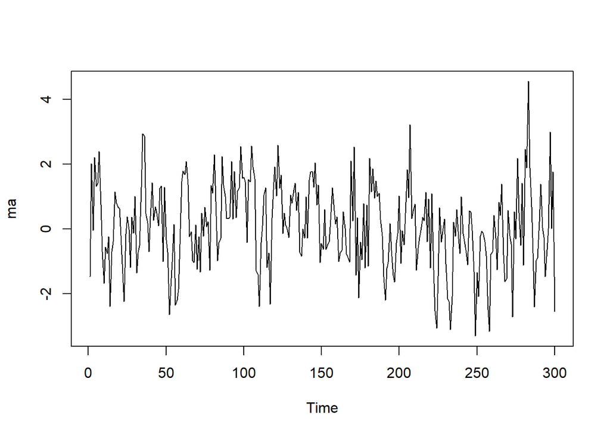

```r
ts.plot(ma)
```

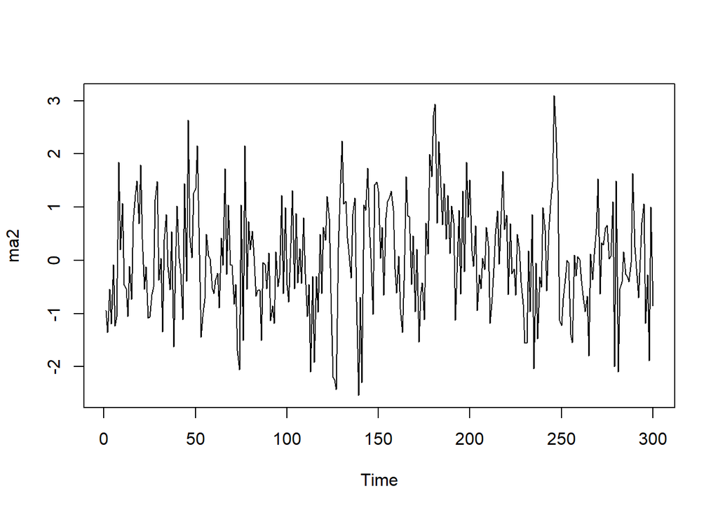

```r
ts.plot(ma2)
```

Berdasarkan plot time series, terlihat bahwa data MA(2) yang dibangkitkan stasioner dalam rataan

### Plot ACF

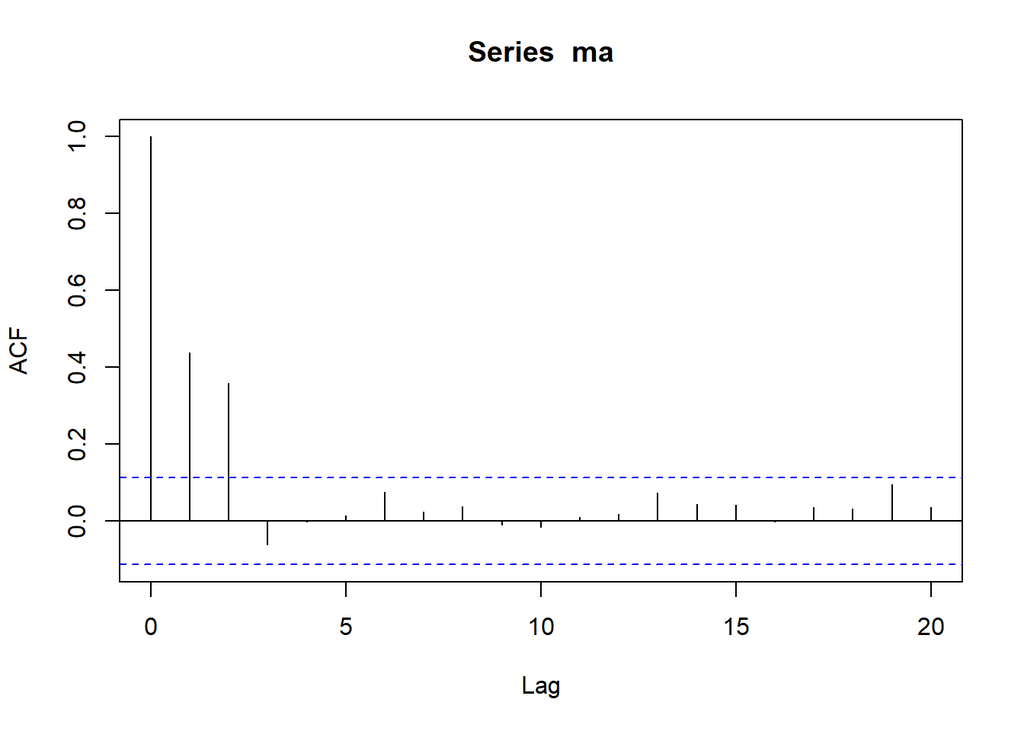

```r
acf(ma,lag.max = 20)
```

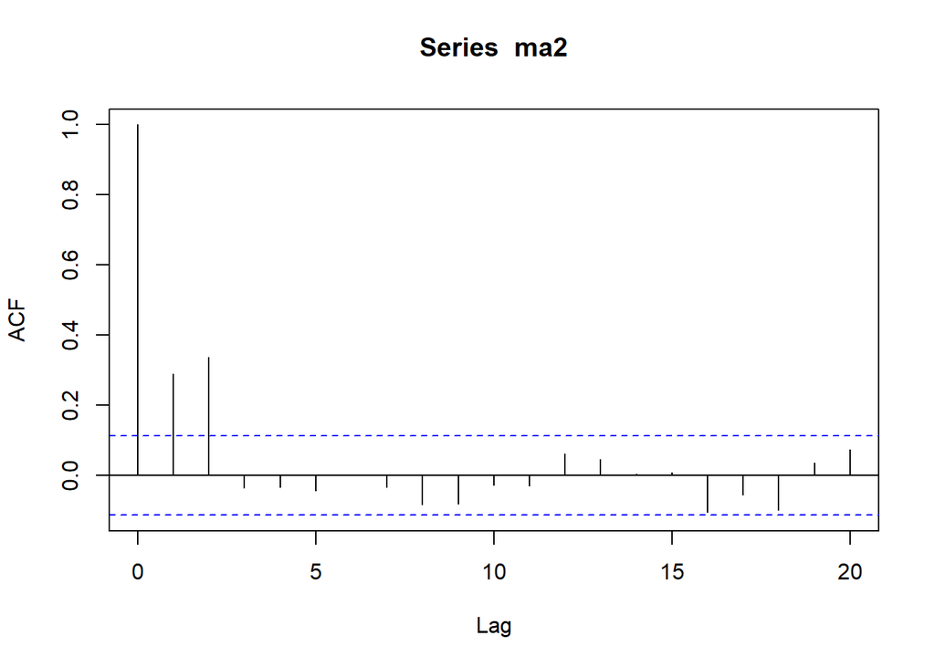

```r
acf(ma2,lag.max = 20)
```

### Plot PACF

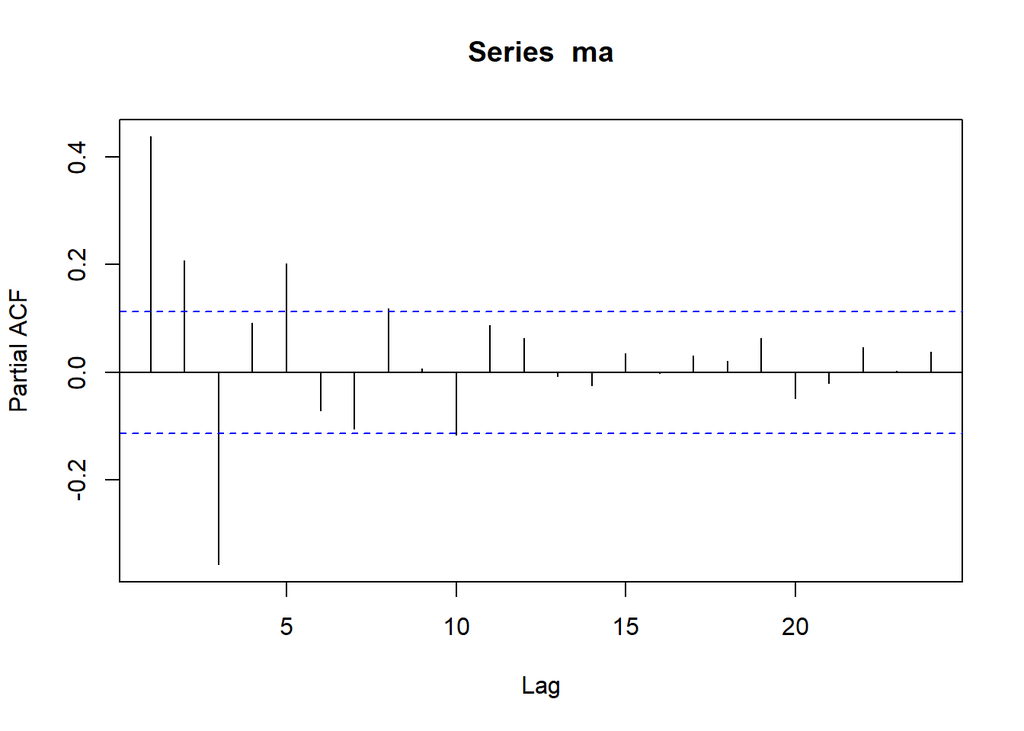

```r
pacf(ma)
```

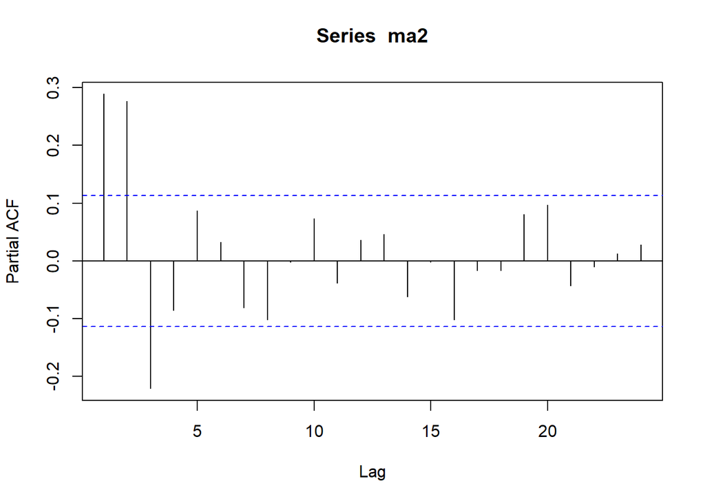

```r
pacf(ma2)
```

Berdasarkan plot PACF tersebut, terlihat bahwa plot PACF cenderung *tails off* dan membentuk gelombang sinus

### Plot EACF

```r
TSA::eacf(ma)
```

```
## AR/MA
##   0 1 2 3 4 5 6 7 8 9 10 11 12 13
## 0 x x o o o o o o o o o  o  o  o
## 1 x x o o o o o o o o o  o  o  o
## 2 x x o o o o o o o o o  o  o  o
## 3 x x o o x o o o o o o  o  o  o
## 4 x x o x x x o o o o o  o  o  o
## 5 x x o x x x x o o o o  o  o  o
## 6 x x o o o o x x o o o  o  o  o
## 7 x x o o o o x o x o o  o  o  o
```

```r
TSA::eacf(ma2)
```

```
## AR/MA
##   0 1 2 3 4 5 6 7 8 9 10 11 12 13
## 0 x x o o o o o o o o o  o  o  o
## 1 x x x o o o o o o o o  o  o  o
## 2 x x x x o o o o o o o  o  o  o
## 3 x x o x o o o o o o o  o  o  o
## 4 x x o o x o o o o o o  o  o  o
## 5 x x x o o o o o o o o  o  o  o
## 6 x x o x o o o x o o o  o  o  o
## 7 x x o o x o x x x o o  o  o  o
```

Berdasarkan pola segitiga nol pada plot EACF, terlihat bahwa segitiga nol berada pada ordo AR(0) dan ordo MA(2)

### Scatterplot Antar Lag

#### Korelasi antara $Y_t$ dengan $Y_{t-1}$

```r
#Yt
yt_ma <- ma[-1]
yt_ma
```

```
##   [1]  2.018194204 -0.037321398  2.207789628  1.321635177  1.418503412
##   [6]  2.386721617  0.761864957 -0.700013958 -1.669119398 -0.562353857
##  [11] -0.758113594 -0.228701184 -2.384695368 -0.700762798 -0.395542771
##  [16]  1.149349885  0.810867222  0.667099806  0.627940686 -0.195391124
##  [21] -1.373727403 -2.228933652 -0.145201227  0.381400717 -0.015009576
##  [26] -1.183671644  0.368739310 -0.124347880  1.009261216 -1.360401483
##  [31] -0.727153707 -0.517002982  1.295448000  2.934500887  2.867601065
##  [36]  0.478967796  0.184290325 -0.700136581  0.393597116  1.431157016
##  [41]  0.266501667  0.684708483  0.495648728  0.105008835  1.261688902
##  [46]  1.336396580 -1.008112472  1.284067010 -0.331919509 -0.703999338
##  [51] -2.647103465 -1.778571681 -1.020233570  0.143856107 -2.348151877
##  [56] -2.192352610 -1.860277840 -0.001971726  1.472464030  1.795526681
##  [61]  1.686673369  2.084494636  1.365956368 -0.233919864 -0.074854046
##  [66] -0.975522092 -1.031176686  0.130163870 -1.247459271 -0.239094920
##  [71] -1.325299862  0.484956954 -0.216970081  0.672303509  0.077569777
```

[output cut: 45 more lines]

```r
#Yt-1
yt_1_ma <- ma[-300]
yt_1_ma
```

```
##   [1] -1.468167041  2.018194204 -0.037321398  2.207789628  1.321635177
##   [6]  1.418503412  2.386721617  0.761864957 -0.700013958 -1.669119398
##  [11] -0.562353857 -0.758113594 -0.228701184 -2.384695368 -0.700762798
##  [16] -0.395542771  1.149349885  0.810867222  0.667099806  0.627940686
##  [21] -0.195391124 -1.373727403 -2.228933652 -0.145201227  0.381400717
##  [26] -0.015009576 -1.183671644  0.368739310 -0.124347880  1.009261216
##  [31] -1.360401483 -0.727153707 -0.517002982  1.295448000  2.934500887
##  [36]  2.867601065  0.478967796  0.184290325 -0.700136581  0.393597116
##  [41]  1.431157016  0.266501667  0.684708483  0.495648728  0.105008835
##  [46]  1.261688902  1.336396580 -1.008112472  1.284067010 -0.331919509
##  [51] -0.703999338 -2.647103465 -1.778571681 -1.020233570  0.143856107
##  [56] -2.348151877 -2.192352610 -1.860277840 -0.001971726  1.472464030
##  [61]  1.795526681  1.686673369  2.084494636  1.365956368 -0.233919864
##  [66] -0.074854046 -0.975522092 -1.031176686  0.130163870 -1.247459271
##  [71] -0.239094920 -1.325299862  0.484956954 -0.216970081  0.672303509
```

[output cut: 45 more lines]

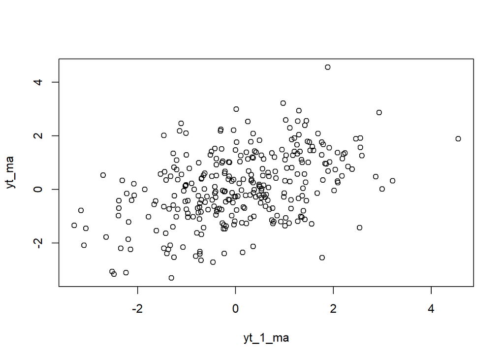

```r
plot(y=yt_ma,x=yt_1_ma)
```

Berdasarkan scatterplot tersebut, terlihat bahwa terdapat hubungan positif antara $Y_t$ dengan $Y_{t-1}$. Hal ini sesuai dengan teori yang ada

```r
cor(yt_ma,yt_1_ma)
```

```
## [1] 0.4417977
```

#### Korelasi antara $Y_t$ dengan $Y_{t-2}$

```r
#Yt
yt_ma2 <- ma[-c(1,2)]
yt_ma2
```

```
##   [1] -0.037321398  2.207789628  1.321635177  1.418503412  2.386721617
##   [6]  0.761864957 -0.700013958 -1.669119398 -0.562353857 -0.758113594
##  [11] -0.228701184 -2.384695368 -0.700762798 -0.395542771  1.149349885
##  [16]  0.810867222  0.667099806  0.627940686 -0.195391124 -1.373727403
##  [21] -2.228933652 -0.145201227  0.381400717 -0.015009576 -1.183671644
##  [26]  0.368739310 -0.124347880  1.009261216 -1.360401483 -0.727153707
##  [31] -0.517002982  1.295448000  2.934500887  2.867601065  0.478967796
##  [36]  0.184290325 -0.700136581  0.393597116  1.431157016  0.266501667
##  [41]  0.684708483  0.495648728  0.105008835  1.261688902  1.336396580
##  [46] -1.008112472  1.284067010 -0.331919509 -0.703999338 -2.647103465
##  [51] -1.778571681 -1.020233570  0.143856107 -2.348151877 -2.192352610
##  [56] -1.860277840 -0.001971726  1.472464030  1.795526681  1.686673369
##  [61]  2.084494636  1.365956368 -0.233919864 -0.074854046 -0.975522092
##  [66] -1.031176686  0.130163870 -1.247459271 -0.239094920 -1.325299862
##  [71]  0.484956954 -0.216970081  0.672303509  0.077569777  0.222790012
```

[output cut: 45 more lines]

```r
#Yt-2
yt_2_ma <- ma[-c(299,300)]
yt_2_ma
```

```
##   [1] -1.468167041  2.018194204 -0.037321398  2.207789628  1.321635177
##   [6]  1.418503412  2.386721617  0.761864957 -0.700013958 -1.669119398
##  [11] -0.562353857 -0.758113594 -0.228701184 -2.384695368 -0.700762798
##  [16] -0.395542771  1.149349885  0.810867222  0.667099806  0.627940686
##  [21] -0.195391124 -1.373727403 -2.228933652 -0.145201227  0.381400717
##  [26] -0.015009576 -1.183671644  0.368739310 -0.124347880  1.009261216
##  [31] -1.360401483 -0.727153707 -0.517002982  1.295448000  2.934500887
##  [36]  2.867601065  0.478967796  0.184290325 -0.700136581  0.393597116
##  [41]  1.431157016  0.266501667  0.684708483  0.495648728  0.105008835
##  [46]  1.261688902  1.336396580 -1.008112472  1.284067010 -0.331919509
##  [51] -0.703999338 -2.647103465 -1.778571681 -1.020233570  0.143856107
##  [56] -2.348151877 -2.192352610 -1.860277840 -0.001971726  1.472464030
##  [61]  1.795526681  1.686673369  2.084494636  1.365956368 -0.233919864
##  [66] -0.074854046 -0.975522092 -1.031176686  0.130163870 -1.247459271
##  [71] -0.239094920 -1.325299862  0.484956954 -0.216970081  0.672303509
```

[output cut: 45 more lines]

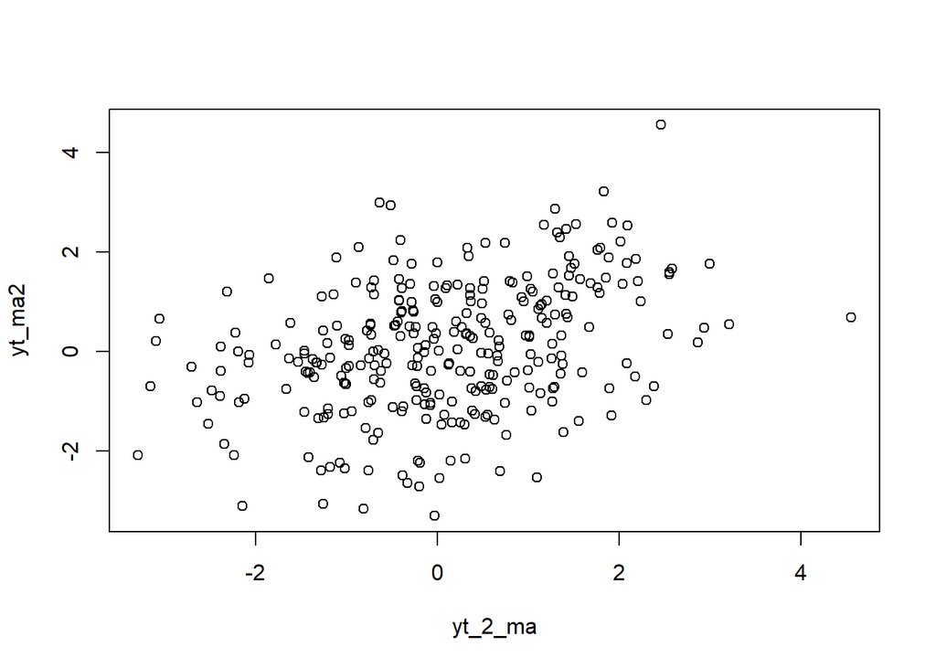

```r
plot(y=yt_ma2,x=yt_2_ma)
```

```r
cor(yt_ma2,yt_2_ma)
```

```
## [1] 0.3653294
```

## Proses AR

Proses AR dapat dituliskan sebagai berikut:

$$y_{t} = c + e_t + \phi_{1}Y_{t-1} +
\phi_{2}Y_{t-2} + \dots + \phi_{q}Y_{t-q} = c+{e_t+\sum_{i=1}^p
\phi_iY_{t-i}}$$
Terlihat bahwa $Y_t$ berperan penting dalam pembangkitan proses AR.

## Pembangkitan Proses AR

```r
set.seed(082)
```

Nilai-nilai selanjutnya dapat dicari melalui *loop*. Bentuk loop dapat dilihat dari rumus AR(2) yang hendak dibangkitkan:

$$Y_t =
e_t+0.5Y_{t-1}+0.2Y_{t-2}$$

```r
n<-length(wn)
n
```

```
## [1] 300
```

```r
ar <- c(1:n)
for (i in 3:n) {ar[i]<-wn[i]+0.5*ar[i-1]+0.2*ar[i-2]}
ar
```

```
##   [1]  1.000000000  2.000000000  1.236301145  2.000503221  2.154425270
##   [6]  1.943639730  3.058747897  1.737753790 -0.140874029 -0.635196590
##  [11]  0.429697478 -0.433106204 -0.616230888 -2.272635765 -0.917796857
##  [16] -0.318935786  0.363466381  0.289521920  0.392027500  0.709083982
##  [21] -0.049253931 -1.336756512 -2.036263304 -0.015102671  0.273265165
##  [26] -0.918853363 -1.580300625  0.496508362 -0.075009377  0.191681965
##  [31] -1.327194308 -0.867132090 -0.274439308  0.960098485  2.596625086
##  [36]  2.726901089  0.564237595  0.797263218  0.614559646  0.837238854
##  [41]  1.762637506  0.604521898  0.784531093  1.223468373  0.511684276
##  [46]  1.438828098  1.937004247 -0.760921438  1.428730807  0.871858845
##  [51] -0.959269252 -2.465795025 -1.330543275 -0.920028146 -0.734152472
##  [56] -3.039063343 -2.858704339 -1.927716922 -0.865944917  0.320417673
##  [61]  0.925180480  1.154722783  2.032776144  1.728308129  0.082172035
##  [66]  0.498723200 -0.041393953 -0.896438373  0.248174284 -0.999237086
##  [71] -0.734267341 -1.212145556  0.160666689 -0.357404341  0.055702345
```

[output cut: 45 more lines]

Selain menggunakan cara di atas, pembangkitan proses AR dapat dilakukan dengan fungsi `arima.sim()` sebagai berikut.

```r
ar2 <- arima.sim(list(order=c(2,0,0), ar=c(0.5,0.2)), n=300)
ar2
```

```
## Time Series:
## Start = 1
## End = 300
## Frequency = 1
##   [1] -0.266823291 -1.226870477 -0.588587518 -0.356937165  0.724056629
##   [6]  1.253300915 -0.594263637 -0.042340198 -0.668006327  0.258855265
##  [11]  0.935305865 -0.338240290 -0.755424653  0.919083665 -1.394217124
##  [16] -0.765269114  1.485923747 -0.075440610 -1.005094156 -0.721840267
##  [21]  1.724131081 -0.468314659  1.844292511  1.272439159 -0.162524123
##  [26]  1.635401815  2.251948859  2.139761250  0.478572996 -0.772681887
##  [31] -0.154991927 -0.146302567  0.266389588 -0.006497128 -0.095332840
##  [36] -0.446330842 -0.619973978 -0.380681010 -0.334791813 -1.144433732
##  [41]  0.151736925 -0.017405993  1.214763992 -0.212964928  0.788964099
##  [46]  0.500403590 -0.133668169 -0.661418466 -0.204625165 -1.576223742
##  [51] -2.443516307  0.953518635 -1.542073609  0.690799328 -0.095272785
```

[output cut: 49 more lines]

## Karakteristik AR(2)

### Plot Time Series

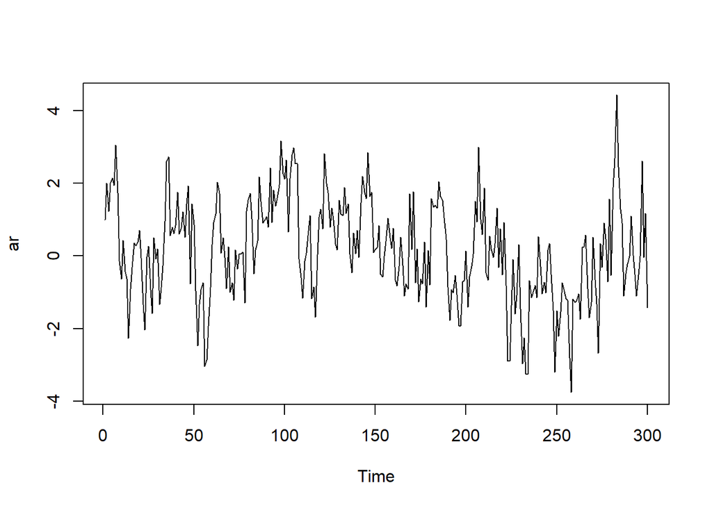

```r
ts.plot(ar)
```

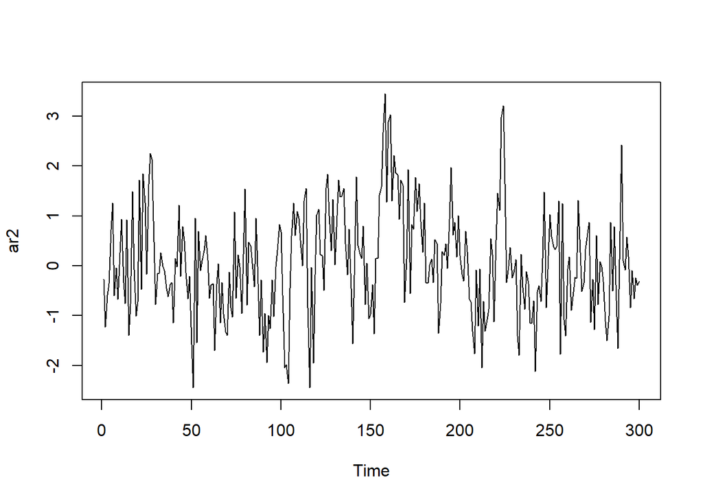

```r
ts.plot(ar2)
```

Berdasarkan plot time series tersebut terlihat bahwa data cenderung stasioner pada rataan

### Plot ACF

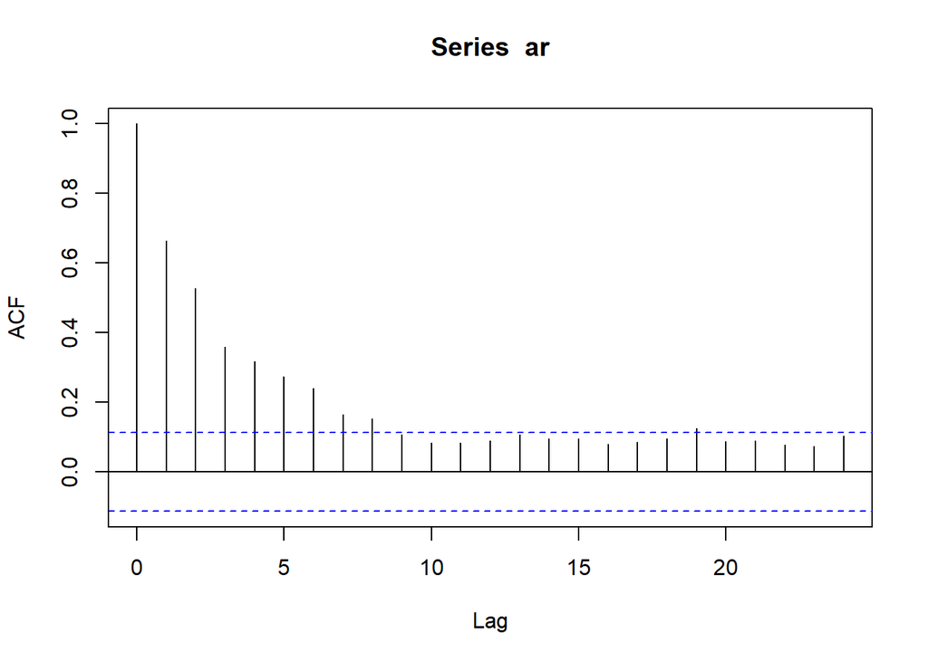

```r
acf(ar)
```

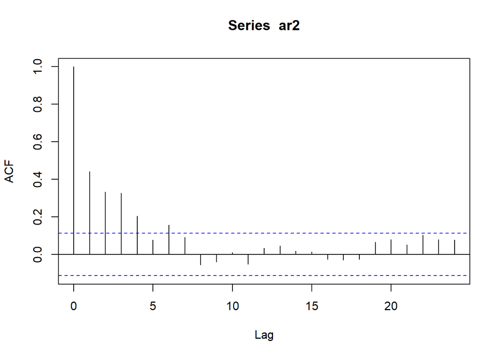

```r
acf(ar2)
```

Berdasarkan plot ACF tersebut terlihat bahwa plot ACF cenderung *tails off* dan cenderung membentuk pola grafik sinus

### Plot PACF

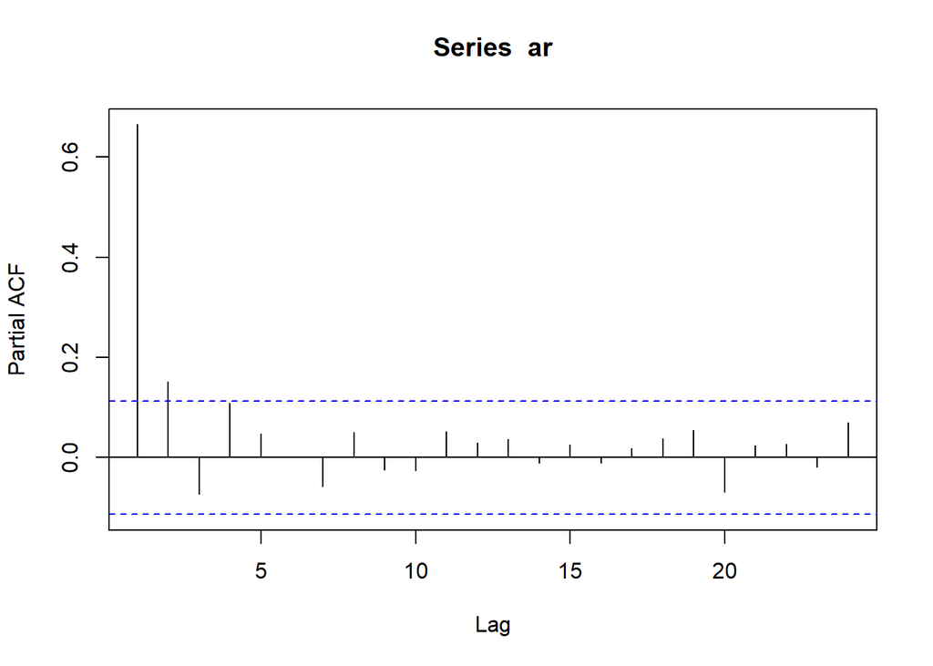

```r
pacf(ar)
```

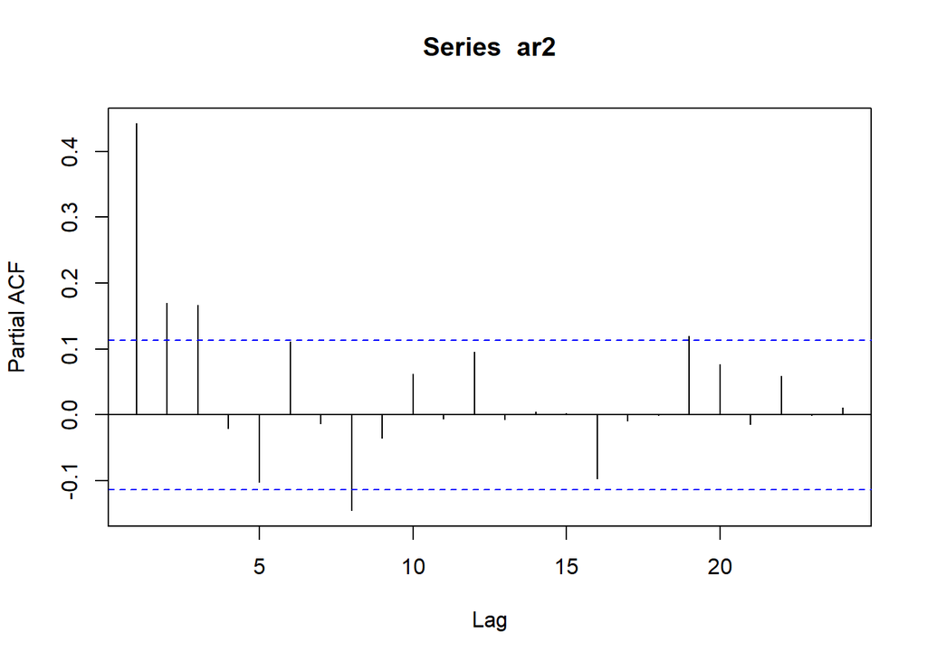

```r
pacf(ar2)
```

### Plot EACF

```r
TSA::eacf(ar)
```

```
## AR/MA
##   0 1 2 3 4 5 6 7 8 9 10 11 12 13
## 0 x x x x x x x x o o o  o  o  o
## 1 x x x o o o o o o o o  o  o  o
## 2 x o x o o o o o o o o  o  o  o
## 3 x x x o o o o o o o o  o  o  o
## 4 x o x x o o o o o o o  o  o  o
## 5 x o x o o o o o o o o  o  o  o
## 6 x x o o o o o o o o o  o  o  o
## 7 x x x o o o o o o o o  o  o  o
```

```r
TSA::eacf(ar2)
```

```
## AR/MA
##   0 1 2 3 4 5 6 7 8 9 10 11 12 13
## 0 x x x x o x o o o o o  o  o  o
## 1 x o x o o x o x o o o  o  o  o
## 2 x x x o x x o o o o o  o  o  o
## 3 o x x o o o o o o o o  o  o  o
## 4 x x o x o o o o o o o  o  o  o
## 5 x x o o o o o o o o o  o  o  o
## 6 o x x x x o o o x o o  o  o  o
## 7 o x x o x o x o o o o  o  o  o
```

### Scatterplot Antar Lag

#### Korelasi antara $Y_t$ dengan $Y_{t-1}$

```r
#Yt
yt_ar <- ar[-1]
yt_ar
```

```
##   [1]  2.000000000  1.236301145  2.000503221  2.154425270  1.943639730
##   [6]  3.058747897  1.737753790 -0.140874029 -0.635196590  0.429697478
##  [11] -0.433106204 -0.616230888 -2.272635765 -0.917796857 -0.318935786
##  [16]  0.363466381  0.289521920  0.392027500  0.709083982 -0.049253931
##  [21] -1.336756512 -2.036263304 -0.015102671  0.273265165 -0.918853363
##  [26] -1.580300625  0.496508362 -0.075009377  0.191681965 -1.327194308
##  [31] -0.867132090 -0.274439308  0.960098485  2.596625086  2.726901089
##  [36]  0.564237595  0.797263218  0.614559646  0.837238854  1.762637506
##  [41]  0.604521898  0.784531093  1.223468373  0.511684276  1.438828098
##  [46]  1.937004247 -0.760921438  1.428730807  0.871858845 -0.959269252
##  [51] -2.465795025 -1.330543275 -0.920028146 -0.734152472 -3.039063343
##  [56] -2.858704339 -1.927716922 -0.865944917  0.320417673  0.925180480
##  [61]  1.154722783  2.032776144  1.728308129  0.082172035  0.498723200
##  [66] -0.041393953 -0.896438373  0.248174284 -0.999237086 -0.734267341
##  [71] -1.212145556  0.160666689 -0.357404341  0.055702345  0.070216755
```

[output cut: 45 more lines]

```r
#Yt-1
yt_1_ar <- ar[-300]
yt_1_ar
```

```
##   [1]  1.000000000  2.000000000  1.236301145  2.000503221  2.154425270
##   [6]  1.943639730  3.058747897  1.737753790 -0.140874029 -0.635196590
##  [11]  0.429697478 -0.433106204 -0.616230888 -2.272635765 -0.917796857
##  [16] -0.318935786  0.363466381  0.289521920  0.392027500  0.709083982
##  [21] -0.049253931 -1.336756512 -2.036263304 -0.015102671  0.273265165
##  [26] -0.918853363 -1.580300625  0.496508362 -0.075009377  0.191681965
##  [31] -1.327194308 -0.867132090 -0.274439308  0.960098485  2.596625086
##  [36]  2.726901089  0.564237595  0.797263218  0.614559646  0.837238854
##  [41]  1.762637506  0.604521898  0.784531093  1.223468373  0.511684276
##  [46]  1.438828098  1.937004247 -0.760921438  1.428730807  0.871858845
##  [51] -0.959269252 -2.465795025 -1.330543275 -0.920028146 -0.734152472
##  [56] -3.039063343 -2.858704339 -1.927716922 -0.865944917  0.320417673
##  [61]  0.925180480  1.154722783  2.032776144  1.728308129  0.082172035
##  [66]  0.498723200 -0.041393953 -0.896438373  0.248174284 -0.999237086
##  [71] -0.734267341 -1.212145556  0.160666689 -0.357404341  0.055702345
```

[output cut: 45 more lines]

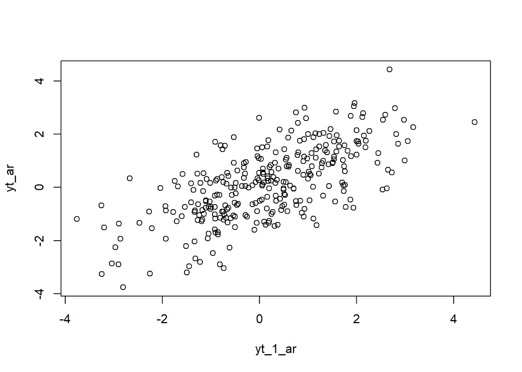

```r
plot(y=yt_ar,x=yt_1_ar)
```

Berdasarkan scatterplot tersebut, terlihat bahwa terdapat hubungan positif antara $Y_t$ dengan $Y_{t-1}$. Hal ini sesuai dengan teori yang ada

```r
cor(yt_ar,yt_1_ar)
```

```
## [1] 0.6668266
```

#### Korelasi antara $Y_t$ dengan $Y_{t-2}$

```r
#Yt
yt_ar2 <- ar[-c(1,2)]
yt_ar2
```

```
##   [1]  1.236301145  2.000503221  2.154425270  1.943639730  3.058747897
##   [6]  1.737753790 -0.140874029 -0.635196590  0.429697478 -0.433106204
##  [11] -0.616230888 -2.272635765 -0.917796857 -0.318935786  0.363466381
##  [16]  0.289521920  0.392027500  0.709083982 -0.049253931 -1.336756512
##  [21] -2.036263304 -0.015102671  0.273265165 -0.918853363 -1.580300625
##  [26]  0.496508362 -0.075009377  0.191681965 -1.327194308 -0.867132090
##  [31] -0.274439308  0.960098485  2.596625086  2.726901089  0.564237595
##  [36]  0.797263218  0.614559646  0.837238854  1.762637506  0.604521898
##  [41]  0.784531093  1.223468373  0.511684276  1.438828098  1.937004247
##  [46] -0.760921438  1.428730807  0.871858845 -0.959269252 -2.465795025
##  [51] -1.330543275 -0.920028146 -0.734152472 -3.039063343 -2.858704339
##  [56] -1.927716922 -0.865944917  0.320417673  0.925180480  1.154722783
##  [61]  2.032776144  1.728308129  0.082172035  0.498723200 -0.041393953
##  [66] -0.896438373  0.248174284 -0.999237086 -0.734267341 -1.212145556
##  [71]  0.160666689 -0.357404341  0.055702345  0.070216755  0.102137572
```

[output cut: 45 more lines]

```r
#Yt-2
yt_2_ar <- ar[-c(299,300)]
yt_2_ar
```

```
##   [1]  1.000000000  2.000000000  1.236301145  2.000503221  2.154425270
##   [6]  1.943639730  3.058747897  1.737753790 -0.140874029 -0.635196590
##  [11]  0.429697478 -0.433106204 -0.616230888 -2.272635765 -0.917796857
##  [16] -0.318935786  0.363466381  0.289521920  0.392027500  0.709083982
##  [21] -0.049253931 -1.336756512 -2.036263304 -0.015102671  0.273265165
##  [26] -0.918853363 -1.580300625  0.496508362 -0.075009377  0.191681965
##  [31] -1.327194308 -0.867132090 -0.274439308  0.960098485  2.596625086
##  [36]  2.726901089  0.564237595  0.797263218  0.614559646  0.837238854
##  [41]  1.762637506  0.604521898  0.784531093  1.223468373  0.511684276
##  [46]  1.438828098  1.937004247 -0.760921438  1.428730807  0.871858845
##  [51] -0.959269252 -2.465795025 -1.330543275 -0.920028146 -0.734152472
##  [56] -3.039063343 -2.858704339 -1.927716922 -0.865944917  0.320417673
##  [61]  0.925180480  1.154722783  2.032776144  1.728308129  0.082172035
##  [66]  0.498723200 -0.041393953 -0.896438373  0.248174284 -0.999237086
##  [71] -0.734267341 -1.212145556  0.160666689 -0.357404341  0.055702345
```

[output cut: 45 more lines]

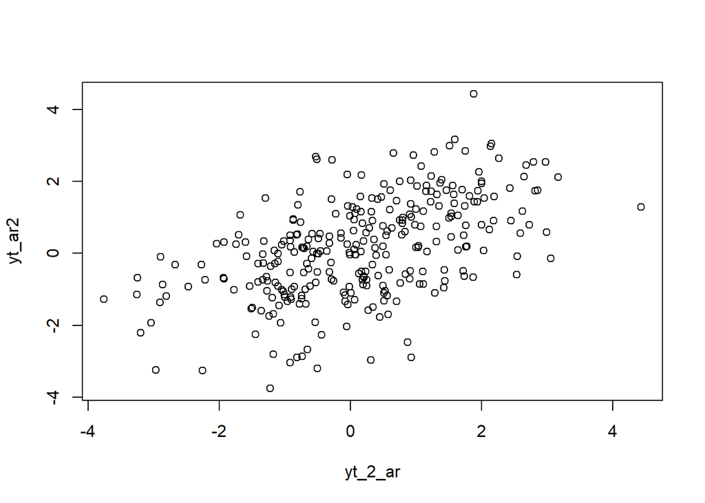

```r
plot(y=yt_ar2,x=yt_2_ar)
```

Berdasarkan scatterplot tersebut, terlihat bahwa terdapat hubungan positif antara $Y_t$ dengan $Y_{t-2}$. Hal ini sesuai dengan teori yang ada

```r
cor(yt_ar2,yt_2_ar)
```

```
## [1] 0.5303307
```

## Fungsi pembangkitan ARMA

Bentuk umum data berpola ARMA.

$$y_{t} = c + \sum_{i=1}^p \phi_{i}y_{t-i} + \sum_{j=1}^q e_{t-j}+ e_{t}$$

```r
set.seed(082)
n = length(wn)
phi1 = 0.5
phi2 = 0.2
theta1 = 0.4
theta2 = 0.6

y.arma=c(1:n)
for (i in 3:n){y.arma[i] = phi1*y.arma[i-1] + phi2*y.arma[i-2] + theta1*wn[i-1] + theta2*wn[i-2] + wn[i]}
y.arma
```

```
##   [1]  1.000000000  2.000000000  1.162678602  3.189128929  3.148735362
##   [6]  3.630696879  4.831817129  3.903912898  2.218305916  0.220816140
##  [11] -0.008284604 -0.718092668 -0.589404439 -2.823016121 -2.230151746
##  [16] -2.075221869 -0.334291398  0.228677149  0.714580101  1.030966166
##  [21]  0.463007979 -0.936030181 -2.604347147 -1.634580837 -0.956759130
##  [26] -0.820305309 -1.785176124 -0.687909814 -0.825338012  0.459010247
##  [31] -1.295963962 -1.283333638 -1.417862593  0.329849975  2.815853356
##  [36]  4.341497738  3.212887336  2.659033541  1.271957657  1.561382652
##  [41]  2.466239873  1.811898134  2.083905524  1.899981117  1.471780499
##  [46]  2.377575374  2.819540367  0.877172786  2.286561476  0.986795786
##  [51]  0.246710851 -2.326388882 -2.892423952 -2.931723322 -1.900490344
##  [56] -3.884741714 -4.514821536 -4.894636951 -3.352254508 -1.182590614
##  [61]  0.533780472  1.717045482  3.049773471  3.234252199  1.993160930
##  [66]  1.568576859  0.207398523 -0.613762053 -0.135237452 -1.437830407
##  [71] -0.985057614 -2.105394750 -0.764751943 -1.020425003  0.009140618
```

[output cut: 45 more lines]

Pembangkitan ARMA(p,q) juga dapat dilakukan dengan fungsi `arima.sim` sebagai berikut.

```r
arma22 <- arima.sim(list(order=c(2,0,2), ar = c(0.5,0.2), ma = c(0.4,0.6)), n=300)
arma22
```

```
## Time Series:
## Start = 1
## End = 300
## Frequency = 1
##   [1] -1.23871436 -1.32794913  0.22854498  1.32907820  0.34173232  0.47211909
##   [7] -1.04136017 -0.03364434  0.63812578  0.19125743 -0.32948982  0.41400579
##  [13] -1.47981089 -0.77148475  0.34330185  0.05977963 -0.14370684 -1.16913520
##  [19]  0.83234389 -0.21176226  2.69144844  1.72916977  1.45302887  2.33385705
##  [25]  2.80859617  4.02178269  2.68564743  0.70260453 -0.17692053 -0.67190820
##  [31]  0.11487361  0.01227733  0.06190218 -0.48836216 -0.85570595 -0.89646905
##  [37] -0.85904856 -1.50675903 -0.50691163 -0.64337144  1.29884376  0.26249708
##  [43]  1.43263653  0.68821028  0.53987173 -0.41464358 -0.54939345 -2.05492489
##  [49] -3.19678090 -0.96962213 -2.62677594  0.64608107 -0.74419722  0.48676010
##  [55]  0.29432231  0.79938384  0.54335505 -0.24049481 -0.57596161 -0.90115022
##  [61] -2.07416483 -1.25682090 -1.12258588 -1.34658469 -0.76280882 -1.78860657
```

[output cut: 39 more lines]

## Karakteristik ARMA(2,2)

### Plot Time Series

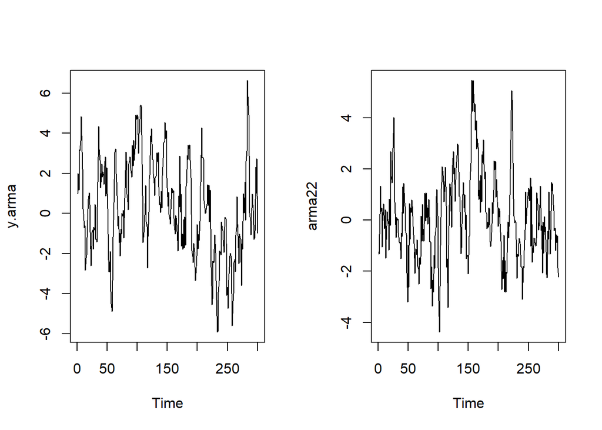

```r
par(mfrow = c(1, 2))
ts.plot(y.arma)
ts.plot(arma22)
```

```r
par(mfrow = c(1, 1))
```

Berdasarkan plot time series tersebut, terlihat bahwa model ARMA(2,2) cenderung stasioner dalam rataan

### Plot ACF

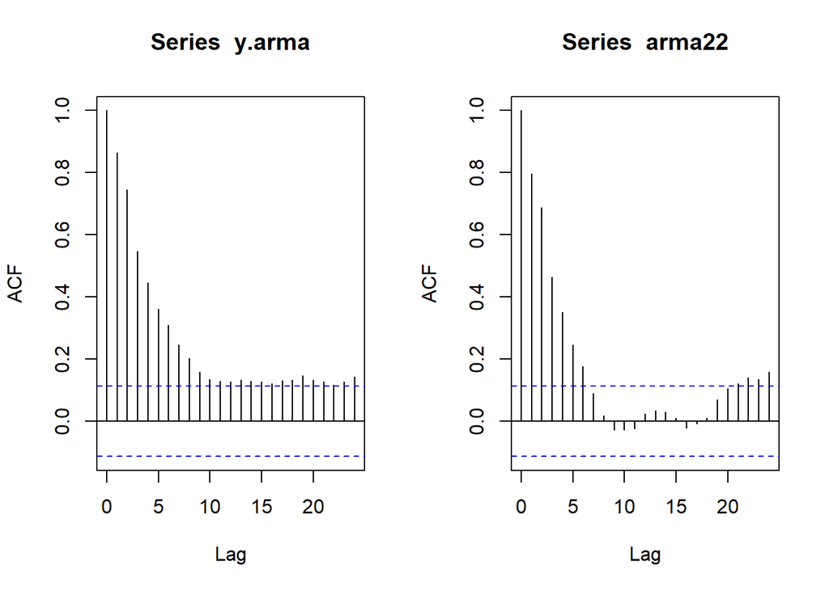

```r
par(mfrow = c(1, 2))
acf(y.arma)
acf(arma22)
```

```r
par(mfrow = c(1, 1))
```

Berdasarkan plot ACF tersebut, terlihat bahwa model ARMA(2,2) hasil simulasi memiliki plot ACF yang *tails off*, sesuai dengan teori yang ada

### Plot PACF

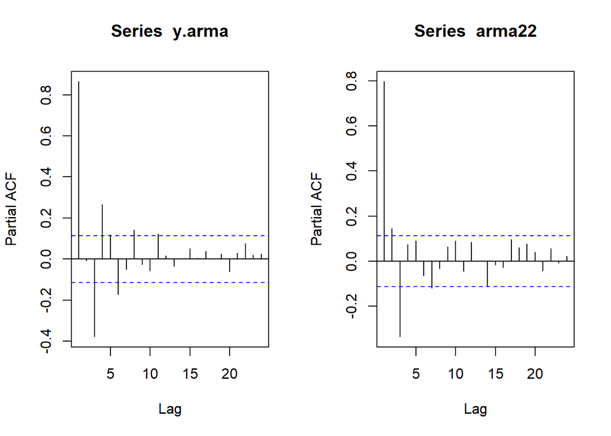

```r
par(mfrow = c(1, 2))
pacf(y.arma)
pacf(arma22)
```

```r
par(mfrow = c(1, 1))
```

Berdasarkan plot PACF tersebut, terlihat bahwa model ARMA(2,2) hasil simulasi memiliki plot PACF yang *tails off*, sesuai dengan teori

### Plot EACF

```r
TSA::eacf(y.arma)
```

```
## AR/MA
##   0 1 2 3 4 5 6 7 8 9 10 11 12 13
## 0 x x x x x x x x x x x  x  x  x
## 1 o x x o o o o o o o o  o  o  o
## 2 o x x o o o o o o o o  o  o  o
## 3 x x x x o o o o o o o  o  o  o
## 4 x x o o o o o o o o o  o  o  o
## 5 x x x o o o o o o o o  o  o  o
## 6 x x x o o o x o o o o  o  o  o
## 7 x x x o o o x x o o o  o  o  o
```

```r
TSA::eacf(arma22)
```

```
## AR/MA
##   0 1 2 3 4 5 6 7 8 9 10 11 12 13
## 0 x x x x x x o o o o o  o  o  o
## 1 x x x o o o o o x o o  o  o  o
## 2 x x o o o o o o x o o  o  o  o
## 3 x x o o o o o o o o o  o  o  o
## 4 x x o o o o o o o o o  o  o  o
## 5 x x o o o o o o o o o  o  o  o
## 6 x x o o o o x o o o o  o  o  o
## 7 x x x o o o x x o o o  o  o  o
```

### Scatterplot Antar Lag

#### Korelasi antara $Y_t$ dengan $Y_{t-1}$

```r
#Yt
yt_arma <- arma22[-1]
yt_arma
```

```
##   [1] -1.32794913  0.22854498  1.32907820  0.34173232  0.47211909 -1.04136017
##   [7] -0.03364434  0.63812578  0.19125743 -0.32948982  0.41400579 -1.47981089
##  [13] -0.77148475  0.34330185  0.05977963 -0.14370684 -1.16913520  0.83234389
##  [19] -0.21176226  2.69144844  1.72916977  1.45302887  2.33385705  2.80859617
##  [25]  4.02178269  2.68564743  0.70260453 -0.17692053 -0.67190820  0.11487361
##  [31]  0.01227733  0.06190218 -0.48836216 -0.85570595 -0.89646905 -0.85904856
##  [37] -1.50675903 -0.50691163 -0.64337144  1.29884376  0.26249708  1.43263653
##  [43]  0.68821028  0.53987173 -0.41464358 -0.54939345 -2.05492489 -3.19678090
##  [49] -0.96962213 -2.62677594  0.64608107 -0.74419722  0.48676010  0.29432231
##  [55]  0.79938384  0.54335505 -0.24049481 -0.57596161 -0.90115022 -2.07416483
##  [61] -1.25682090 -1.12258588 -1.34658469 -0.76280882 -1.78860657 -1.90111020
##  [67] -2.49698988 -1.46921905 -1.72425434 -1.43312590  0.16281775 -0.82794624
##  [73]  0.61347996 -0.32227129 -0.82555240 -0.16057722  1.06257540 -0.03262884
##  [79]  1.07977554  0.11087641  0.49079693 -0.15997913  0.81457835  0.11970630
##  [85] -0.83159534 -0.84729332 -2.68338267 -1.81425724 -3.36370421 -2.34530437
```

[output cut: 35 more lines]

```r
#Yt-1
yt_1_arma <- arma22[-300]
yt_1_arma
```

```
##   [1] -1.23871436 -1.32794913  0.22854498  1.32907820  0.34173232  0.47211909
##   [7] -1.04136017 -0.03364434  0.63812578  0.19125743 -0.32948982  0.41400579
##  [13] -1.47981089 -0.77148475  0.34330185  0.05977963 -0.14370684 -1.16913520
##  [19]  0.83234389 -0.21176226  2.69144844  1.72916977  1.45302887  2.33385705
##  [25]  2.80859617  4.02178269  2.68564743  0.70260453 -0.17692053 -0.67190820
##  [31]  0.11487361  0.01227733  0.06190218 -0.48836216 -0.85570595 -0.89646905
##  [37] -0.85904856 -1.50675903 -0.50691163 -0.64337144  1.29884376  0.26249708
##  [43]  1.43263653  0.68821028  0.53987173 -0.41464358 -0.54939345 -2.05492489
##  [49] -3.19678090 -0.96962213 -2.62677594  0.64608107 -0.74419722  0.48676010
##  [55]  0.29432231  0.79938384  0.54335505 -0.24049481 -0.57596161 -0.90115022
##  [61] -2.07416483 -1.25682090 -1.12258588 -1.34658469 -0.76280882 -1.78860657
##  [67] -1.90111020 -2.49698988 -1.46921905 -1.72425434 -1.43312590  0.16281775
##  [73] -0.82794624  0.61347996 -0.32227129 -0.82555240 -0.16057722  1.06257540
##  [79] -0.03262884  1.07977554  0.11087641  0.49079693 -0.15997913  0.81457835
##  [85]  0.11970630 -0.83159534 -0.84729332 -2.68338267 -1.81425724 -3.36370421
```

[output cut: 35 more lines]

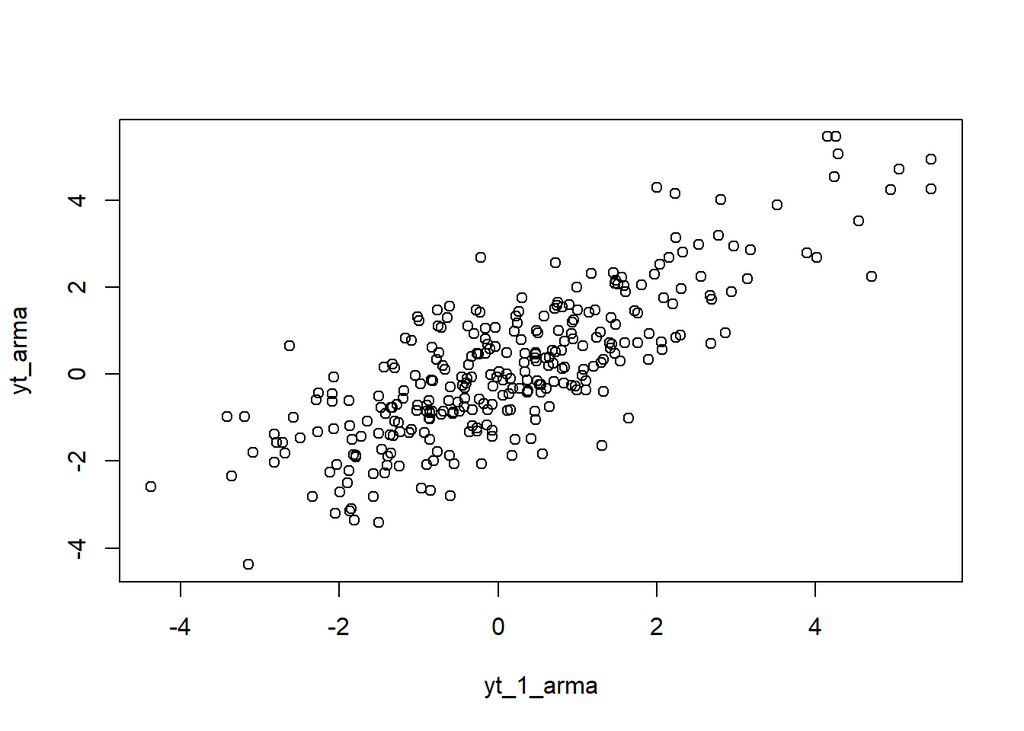

```r
plot(y=yt_arma,x=yt_1_arma)
```

Berdasarkan scatterplot tersebut, terlihat bahwa terdapat hubungan positif antara $Y_t$ dengan $Y_{t-1}$. Hal ini sesuai dengan teori yang ada

```r
cor(yt_arma,yt_1_arma)
```

```
## [1] 0.7999915
```

Korelasi antara $Y_t$ dengan $Y_{t-1}$ dari hasil simulasi mendekati perhitungan teoritis.
$$\rho_k = \frac{(1-\theta
\phi)(\phi-\theta)}{1-2\theta\phi+\theta^2}\phi^{k-1} \:untuk \:k\ge1$$